# ProDA analysis for the CPTAC dataset

Ludger Goeminne

3-12-2019

# Analysis of the Protein Differential Abundance (ProDA) workflow for the CPTAC dataset based on LFQ-summarized data

We base ourselves on the ProDA vignette: https://rdrr.io/bioc/proDA/f/vignettes/Introduction.Rmd.

Set working directory and load all necessary libraries and functions.

```r
# If not installed, install and load the package "here", else: only load the package.
err <- try(library("here", character.only = TRUE), silent = TRUE)
```

```
## here() starts at /Users/lgoeminn/Documents/phD/MSqRobHurdlePaper
```

```r
if (class(err) == 'try-error') {
  install.packages("here", repos = "https://cloud.r-project.org")
  library("here", character.only = TRUE)
}

wd <- here()

# Optional: change the working directory
setwd(wd)

# Load all functions and libraries
source(paste0(wd, "/R/functions.r"))
```

```
##
## This is MSnbase version 2.8.3
##   Visit https://lgatto.github.io/MSnbase/ to get started.
```

Important: make sure you have run 1_analysis_CPTAC_MSqRob.Rmd OR load `peptides.CPTAC` via:

```r
load(paste0(wd, "/save_files_CPTAC/peptides_CPTAC.RData"))
```

## 1. Data import and preprocessing

### 1.1. Import the data

1. **Important:** in the CPTAC dataset, some human UPS proteins are NOT contaminants as these proteins were spiked in on purpose! We only want to remove those contaminants that are not humane UPS proteins. We thus need to unmark these proteins as contaminant before preprocessing.

The following two proteins were manually indicated as not being contaminants in Perseus by removing their corresponding `"+"` symbol in the `"Potential contaminants"` column:

P06396ups;CON__Q3SX14

P02768ups;CON__P02768-1

We saved the new file as **`"proteinGroups_cont_curated.txt"`** (see 6_analysis_CPTAC_Perseus.Rmd).

```r
# Load the table into memory
dataset.CPTAC <- read.delim(
    paste0(wd, "/datasets/CPTAC/proteinGroups_cont_curated.txt"),
    stringsAsFactors = FALSE
)
```

### 1.2. Preprocess data

```r
# Remove reverse sequences, potential contaminants and proteins only identified by modified peptides
dataset.CPTAC <- dataset.CPTAC[rowSums(dataset.CPTAC[,c("Only.identified.by.site", "Reverse", "Potential.contaminant")] == "+") == 0,]

# Use a regex to select the intensity columns
intensity.colnames <- grep("^LFQ\\.intensity\\.", colnames(dataset.CPTAC), value=TRUE)
head(intensity.colnames)
```

```
## [1] "LFQ.intensity.6A_1" "LFQ.intensity.6A_2" "LFQ.intensity.6A_3"
## [4] "LFQ.intensity.6A_4" "LFQ.intensity.6A_5" "LFQ.intensity.6A_6"
```

```r
# Create the intensity matrix
abundance.matrix <- as.matrix(dataset.CPTAC[, intensity.colnames])
# Adapt column and row dataset.CPTAC
colnames(abundance.matrix) <- sub("^LFQ\\.intensity\\.", "", intensity.colnames)
rownames(abundance.matrix) <- dataset.CPTAC$Protein.IDs

# Print some rows of the matrix
head(abundance.matrix)
```

```
##                         6A_1 6A_2 6A_3   6A_4   6A_5   6A_6    6A_7
## A5Z2X5                     0    0    0      0      0      0       0
## P02768ups;CON__P02768-1    0    0    0      0      0      0       0
## D6VTK4                     0    0    0      0      0      0       0
## O00762ups                  0    0    0 486310 443190 417450       0
## O13516                     0    0    0      0      0      0       0
## O13547                     0    0    0      0      0      0 4672700
##                            6A_8    6A_9 6B_1 6B_2 6B_3   6B_4    6B_5
## A5Z2X5                        0       0    0    0    0      0       0
## P02768ups;CON__P02768-1       0       0    0    0    0 192220  162590
## D6VTK4                        0       0    0    0    0      0       0
## O00762ups                407370       0    0    0    0 721110 1028000
## O13516                        0       0    0    0    0      0       0
## O13547                  5345600 4780700    0    0    0      0       0
##                           6B_6    6B_7    6B_8    6B_9 6C_1 6C_2 6C_3
## A5Z2X5                       0       0       0       0    0    0    0
## P02768ups;CON__P02768-1 191680       0       0       0    0    0    0
## D6VTK4                       0       0       0       0    0    0    0
## O00762ups               844220 1212200  724130  999390    0    0    0
## O13516                       0       0       0       0    0    0    0
## O13547                       0 5341800 5316800 4148400    0    0    0
##                            6C_4    6C_5    6C_6    6C_7    6C_8    6C_9
## A5Z2X5                        0       0       0       0       0   81650
## P02768ups;CON__P02768-1  300000  280970  408580       0       0       0
## D6VTK4                        0       0  162800       0       0       0
## O00762ups               1855600 1500300 2171700 3966100 2024700 2644000
## O13516                        0       0       0       0       0  614940
## O13547                        0       0       0 4636600 5795200 5131600
```

```r
# Log2-transform
abundance.matrix[abundance.matrix == 0] <- NA
abundance.matrix <- log2(abundance.matrix)
```

### 1.3. Inspect the data

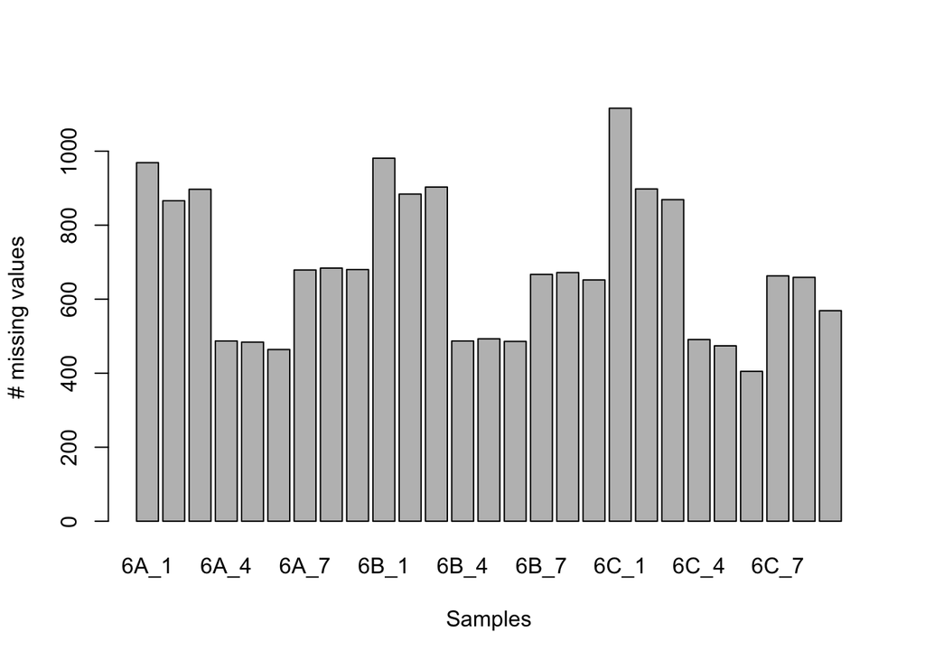

```r
barplot(colSums(is.na(abundance.matrix)),
        ylab = "# missing values",
        xlab = "Samples")
```

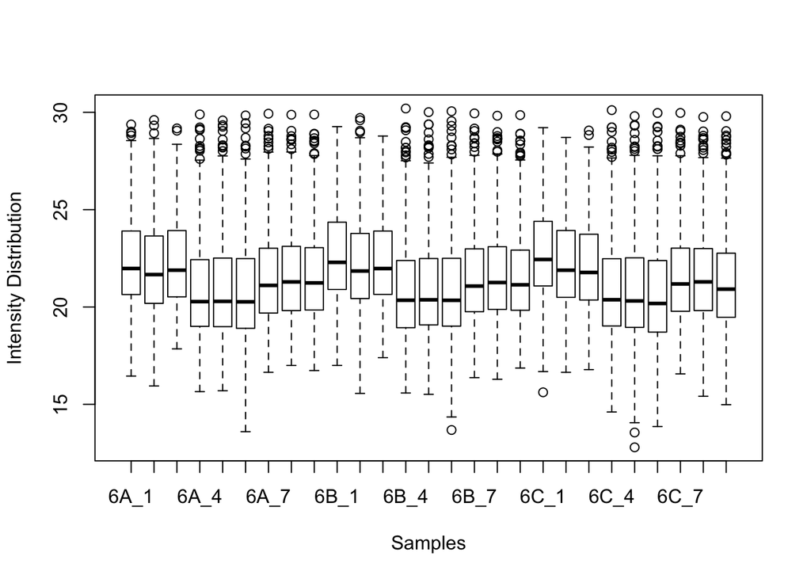

```r
boxplot(abundance.matrix,
        ylab = "Intensity Distribution",
        xlab = "Samples")
```

## 2. ProDA analysis

The vignette suggests the more “conservative” median normalization, which ignores the missing values and transforms the values so that the median difference between the sample and average across all other samples is zero.

```r
normalized.abundance.matrix <- median_normalization(abundance.matrix)
colnames(normalized.abundance.matrix) <- peptides.CPTAC %>% sampleNames
```

```r
annotation <- data.frame(sample = peptides.CPTAC %>% sampleNames %>% as.character, condition = peptides.CPTAC %>% sampleNames %>% substr(2,3) %>% as.character, lab = c("LTQ-Orbitrap_86" %>% rep(3), "LTQ-OrbitrapO_65" %>% rep(3), "LTQ-OrbitrapW_56" %>% rep(3)) %>% rep(3) %>% as.character, stringsAsFactors = FALSE)

fit_ref6A <- proDA(normalized.abundance.matrix, design = ~ condition + lab,
             col_data = annotation, reference_level = "6A")
fit_ref6B <- proDA(normalized.abundance.matrix, design = ~ condition + lab,
             col_data = annotation, reference_level = "6B")
```

```r
res.CPTAC.ProDA_B_A <- test_diff(fit_ref6A, "condition6B")
res.CPTAC.ProDA_B_A$UPS <- grepl("ups", res.CPTAC.ProDA_B_A$name)
res.CPTAC.ProDA_B_A$contrast <- "condition6B-condition6A"
res.CPTAC.ProDA_B_A <- res.CPTAC.ProDA_B_A[,c("name", "UPS", "contrast", "diff", "se",  "t_statistic", "df", "pval", "adj_pval")]
colnames(res.CPTAC.ProDA_B_A) <- c("protein", "UPS", "contrast", "logFC", "se", "t", "df", "pval", "qval")

res.CPTAC.ProDA_C_A <- test_diff(fit_ref6A, "condition6C")
res.CPTAC.ProDA_C_A$UPS <- grepl("ups", res.CPTAC.ProDA_C_A$name)
res.CPTAC.ProDA_C_A$contrast <- "condition6C-condition6A"
res.CPTAC.ProDA_C_A <- res.CPTAC.ProDA_C_A[,c("name", "UPS", "contrast", "diff", "se",  "t_statistic", "df", "pval", "adj_pval")]
colnames(res.CPTAC.ProDA_C_A) <- c("protein", "UPS", "contrast", "logFC", "se", "t", "df", "pval", "qval")

res.CPTAC.ProDA_C_B <- test_diff(fit_ref6B, "condition6C")
res.CPTAC.ProDA_C_B$UPS <- grepl("ups", res.CPTAC.ProDA_C_B$name)
res.CPTAC.ProDA_C_B$contrast <- "condition6C-condition6B"
res.CPTAC.ProDA_C_B <- res.CPTAC.ProDA_C_B[,c("name", "UPS", "contrast", "diff", "se",  "t_statistic", "df", "pval", "adj_pval")]
colnames(res.CPTAC.ProDA_C_B) <- c("protein", "UPS", "contrast", "logFC", "se", "t", "df", "pval", "qval")

res.CPTAC.ProDA <- rbind(res.CPTAC.ProDA_B_A, res.CPTAC.ProDA_C_A, res.CPTAC.ProDA_C_B)
res.CPTAC.ProDA <- as_tibble(res.CPTAC.ProDA)
res.CPTAC.ProDA.full <- res.CPTAC.ProDA %>% arrange(pval)

res.CPTAC.ProDA.full
```

```
## # A tibble: 4,386 x 9
##    protein  UPS   contrast        logFC    se     t    df     pval     qval
##    <chr>    <lgl> <chr>           <dbl> <dbl> <dbl> <dbl>    <dbl>    <dbl>
##  1 P02787u… TRUE  condition6C-co…  4.16 0.158  26.3    22 0.       0.
##  2 P06732u… TRUE  condition6C-co…  3.87 0.145  26.7    22 0.       0.
##  3 P08311u… TRUE  condition6C-co…  3.81 0.142  26.8    22 0.       0.
##  4 Q06830u… TRUE  condition6C-co…  4.02 0.120  33.6    22 0.       0.
##  5 P01031u… TRUE  condition6C-co…  3.50 0.159  21.9    22 2.22e-16 6.49e-14
##  6 P01127u… TRUE  condition6C-co…  3.84 0.182  21.1    22 4.44e-16 9.28e-14
##  7 P10145u… TRUE  condition6C-co…  3.68 0.174  21.1    22 4.44e-16 9.28e-14
##  8 P12081u… TRUE  condition6C-co…  2.74 0.139  19.6    22 2.00e-15 3.65e-13
##  9 P08263u… TRUE  condition6C-co…  3.89 0.206  18.9    22 4.44e-15 7.21e-13
## 10 P63165u… TRUE  condition6C-co…  3.20 0.184  17.4    22 2.35e-14 3.44e-12
## # … with 4,376 more rows
```

```r
# Or load the results:
# load(paste0(wd, "/save_files_CPTAC/res_CPTAC_ProDA_full.RData"))
```